# R-Ladies Mid-Mo

### Viridis

viridis colormaps: “magma” (or “A”), “inferno” (“B”), “plasma” (“C”), “viridis” (“D”), and “cividis” (“E”) viridis direction: 1 colors are ordered from darkest to lightest, -1 the order is reversed begin & end options

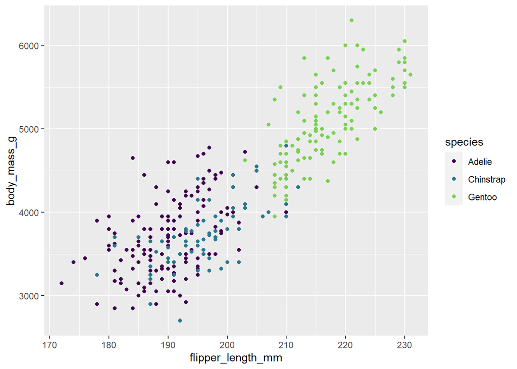

```r
library(viridisLite)
library(viridis)

p + geom_point(aes(color = species)) +
  scale_color_viridis(discrete = TRUE, option = "viridis", direction = 1, end = 0.8)
```

## Changing the legend position

The values for the arguments legend.position are : “left”,“top”, “right”, “bottom”. They can also be a numeric vector c(x,y) with values between 0 and 1. c(0,0) corresponds to the “bottom left” and c(1,1) corresponds to the “top right” position

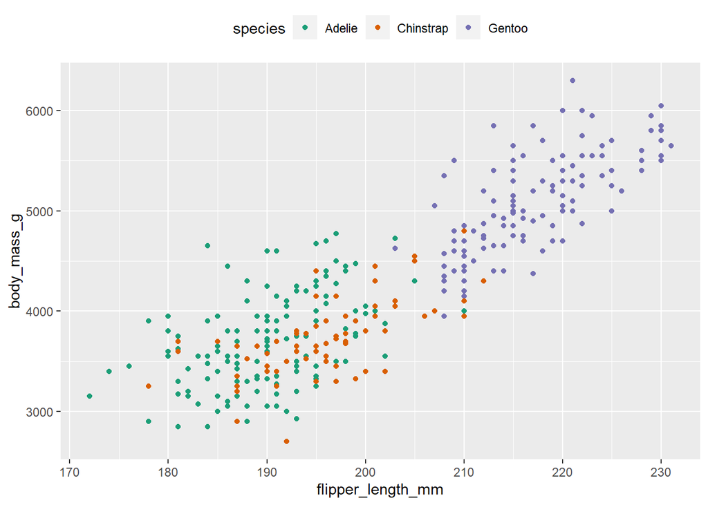

```r
pt + theme(legend.position = "top")
```

```r
# pt + theme(legend.position = c(0, 0.9))
```

## Remove legend, axis titles & axis ticks

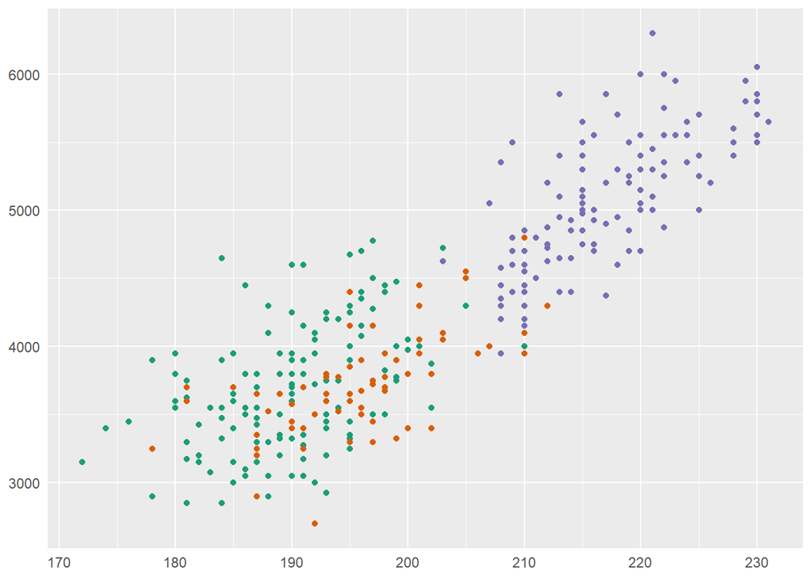

```r
pt + theme(legend.position = "none",
           axis.title = element_blank(),
           axis.ticks = element_blank())
```

## Adding a main title and changing axis titles

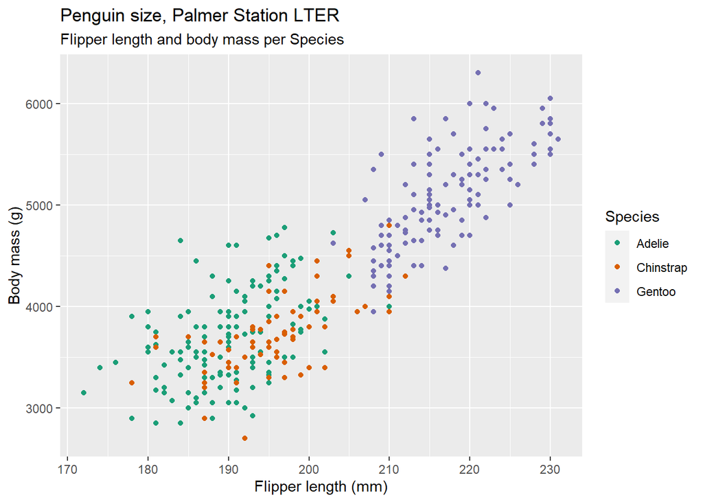

```r
plot <- pt + labs(title = "Penguin size, Palmer Station LTER",
          subtitle = "Flipper length and body mass per Species",
          x = "Flipper length (mm)",
          y = "Body mass (g)",
          color = "Species")

plot
```

### Changing the main title position, font appearance

The most useful arguments of the function element_text() are: *color, size, face, family* To adjust horizontally (hjust) or vertically (vjust) you can use the same values between 0 and 1, as we did before, where 0 corresponds to the “left” and 1 corresponds to the “right” position

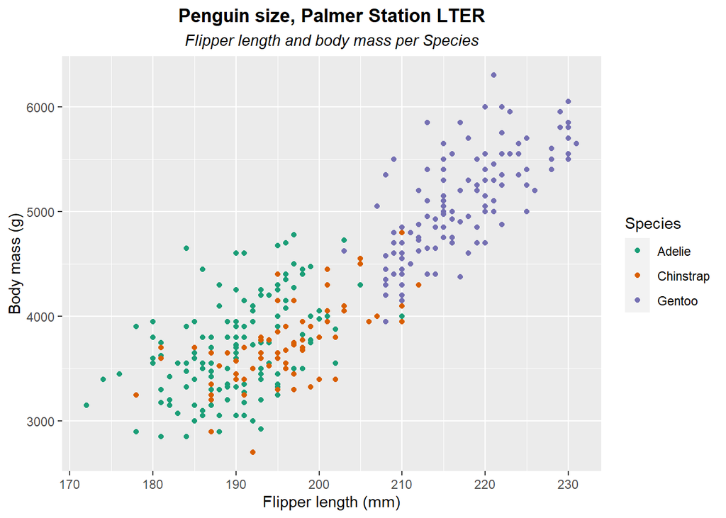

```r
plot + theme(plot.title = element_text(hjust = 0.5, face = "bold"),
             plot.subtitle = element_text(hjust = 0.5, face = "italic"))
```

## Adding a theme

There are many different themes you can use in ggplot2. [Here](https://ggplot2.tidyverse.org/reference/ggtheme.html) is a list of the basic options.

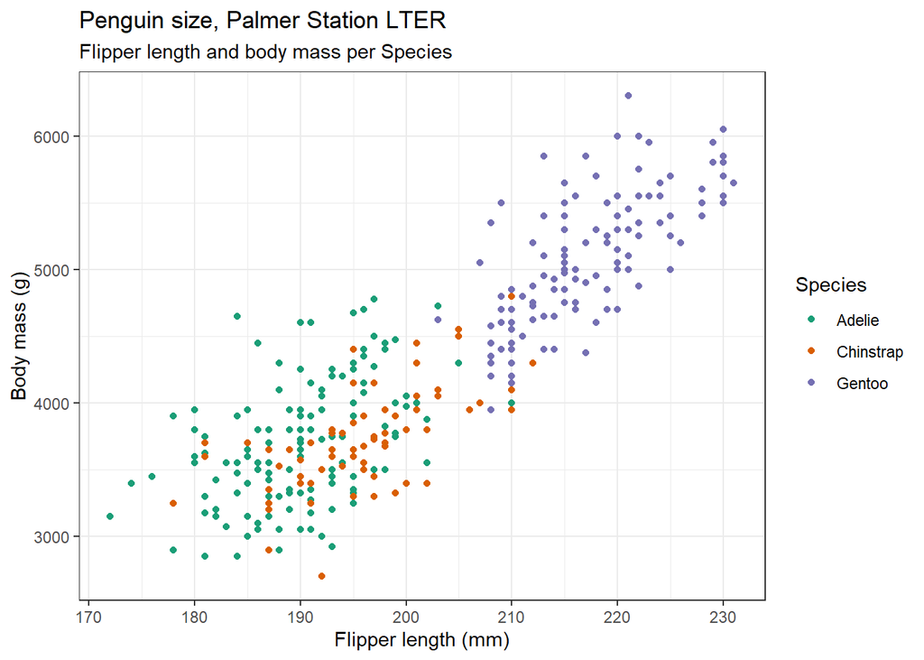

```r
plot + theme_bw()
```

Other Resources:

[R for Data Science](https://r4ds.had.co.nz/data-visualisation.html#fig:shapes) [ggplot](https://ggplot2.tidyverse.org/index.html) [Data Visualization with ggplot2](https://viz-ggplot2.rsquaredacademy.com/index.html) [Data Visualization with R](https://rkabacoff.github.io/datavis/) [Sthda](http://www.sthda.com/english/wiki/ggplot2-point-shapes) [Datanovia](https://www.datanovia.com)